# Handwritten Letter Recognition

**Author: TanVir Hossain**

**Email: hossain.tanvir.m@gmail.com**

In this project we are given a large number of black-and-white rectangular pixel displays. We will use neural networks (MLP) and KNN in order to predict which of the 26 capital letters in the English alphabet each such display represents.

### A: Source Information

Creator: David J. Slate Odesta Corporation; 1890 Maple Ave; Suite 115; Evanston, IL 60201  
Donor: David J. Slate (dave@math.nwu.edu) (708) 491-3867  
Date: January, 1991

### B: Relevant Information

The character images is based on 20 different fonts and each letter within these 20 fonts has been randomly distorted to produce a file of 20,000 unique stimuli. Each stimulus was converted into 16 primitive numerical attributes (statistical moments and edge counts) which were then scaled to fit into a range of integer values from 0 through 15. We typically train on the first 16000 items and then use the resulting model to predict the letter category for the remaining 4000 (**NOT done in this project**). See the article cited below for more details:

P. W. Frey and D. J. Slate (Machine Learning Vol 6 #2 March 91): "Letter Recognition Using Holland-style Adaptive Classifiers".

### C:Attribute Information

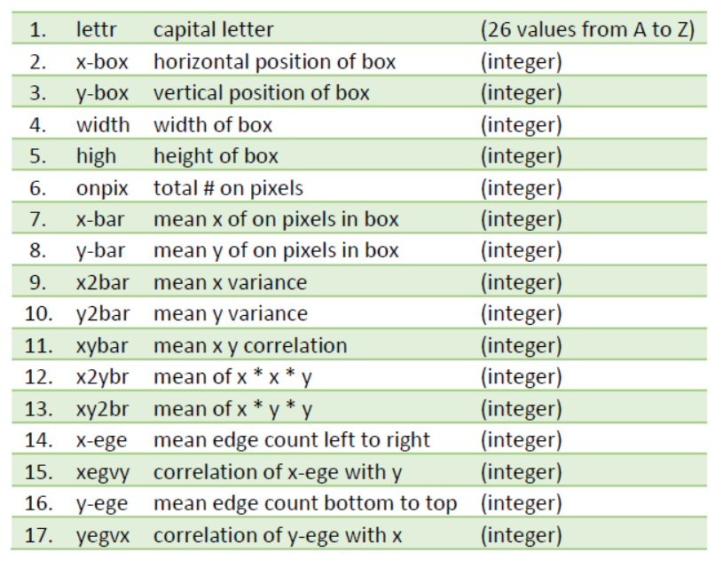

```python
from IPython.display import Image
Image(filename='Att_Letter.png',width = "600",height = "300")
```

**Note**: In the above table, the class label is the **'lettr'** (No.1), following by the 16 numerical attributes (Nos. 2-17).

The following code uses Python's `csv` module to load the data and prints the first row and the total number of rows.

```python
import sklearn
import csv
import pandas as pd
import numpy as np
```

```python
with open('Letter.csv') as f:
    reader = csv.reader(f)
    print("Header line: %s" % next(reader))
    annotated_data = [r for r in reader]
print(annotated_data[0])
print("Total number of rows:", len(annotated_data))
```

```
Header line: ['lettr', 'x-box', 'y-box', 'width', 'high', 'onpix', 'x-bar', 'y-bar', 'x2bar', 'y2bar', 'xybar', 'x2ybr', 'xy2br', 'x-ege', 'xegvy', 'y-ege', 'yegvx']
['T', '2', '8', '3', '5', '1', '8', '13', '0', '6', '6', '10', '8', '0', '8', '0', '8']
Total number of rows: 20000
```

```python
Header=['lettr', 'x-box', 'y-box', 'width', 'high', 'onpix', 'x-bar', 'y-bar', 'x2bar', 'y2bar', 'xybar', 'x2ybr', 'xy2br', 'x-ege', 'xegvy', 'y-ege', 'yegvx']
```

## Class Distribution

Compute and print the percentage and its number of stimuli corresponding to the five letters A-E (class label lettr).

```python
pre_df = pd.DataFrame(columns=Header, data=annotated_data)
```

```python
five_letters=['A', 'B', 'C', 'D', 'E']

for x in five_letters:
    print (x+": "+str(round((pre_df[pre_df['lettr']==x].shape[0]/pre_df.shape[0]*100), 2))+"%")
```

```
A: 3.94%
B: 3.83%
C: 3.68%
D: 4.03%
E: 3.84%
```

## Split the data for training and testing purpose.

Split the data into a training set, a dev-test set, and a test set. Use the following ratio for splitting the data:

- Training set: 80%
- Dev-test set: 10%
- Test set: 10%

```python
import random
random.seed(1234)
random.shuffle(annotated_data)
```

```python
df = pd.DataFrame(columns=Header, data=annotated_data)
```

```python
#function to calculate percent
def percent(number, percent):
    return number * (percent/100)

#Getting the amount of the percentage
p_train = int(percent(df.shape[0], 80))
p_devtest = int(percent(df.shape[0], 10))
p_test = int(percent(df.shape[0], 10))
```

```python
#setting up the range to splite the sets
train, devtest, test = df[:p_train], df[p_train:(p_train+p_devtest)], df[(p_train+p_devtest):df.shape[0]]
```

## Check that the data are balanced

Printing the percentage of class label lettr (A-E) in each partition.

Training set:

```python
for x in five_letters:
    print (x+": "+str(round((train[train['lettr']==x].shape[0]/train.shape[0]*100), 2))+"%")
```

```
A: 3.94%
B: 3.76%
C: 3.61%
D: 4.08%
E: 3.88%
```

Dev-test set:

```python
for x in five_letters:
    print (x+": "+str(round((devtest[devtest['lettr']==x].shape[0]/devtest.shape[0]*100), 2))+"%")
```

```
A: 3.75%
B: 4.5%
C: 3.8%
D: 3.45%
E: 4.2%
```

Test set:

```python
for x in five_letters:
    print (x+": "+str(round((test[test['lettr']==x].shape[0]/test.shape[0]*100), 2))+"%")
```

```
A: 4.2%
B: 3.75%
C: 4.15%
D: 4.2%
E: 3.15%
```

## Training and Testing of Data using MLPClassifier

We will train an `sklearn` MLPClassifier with default settings (random_state=0) using the training set, and report the accuracy on the training and test set respectively.

```python
#Dropping the target attribute and creating X_train
X_train = train.drop(columns='lettr').copy()
X_train = X_train.astype('int')

y_train = train[['lettr']].copy()

#Dropping the target attribute and creating X_devtest
X_devtest = devtest.drop(columns='lettr').copy()
X_devtest = X_devtest.astype('int')

y_devtest = devtest[['lettr']].copy()

#Dropping the target attribute and creating X_test
X_test = test.drop(columns='lettr').copy()
X_test = X_test.astype('int')

y_test = test[['lettr']].copy()
```

```python
from sklearn.neural_network import MLPClassifier
#Training the model with train data
mlp = MLPClassifier(random_state=0).fit(X_train, y_train.values.ravel())
```

```python
#Predicting from the model
pred_train = mlp.predict(X_train)
pred_test = mlp.predict(X_test)
```

```python
from sklearn.metrics import accuracy_score
```

```python
print("Train Set Accuracy: "+str(accuracy_score(y_train, pred_train)*100)+"%")
print("Test Set Accuracy: "+str(accuracy_score(y_test, pred_test)*100)+"%")
```

```
Train Set Accuracy: 94.86875%
Test Set Accuracy: 91.14999999999999%
```

## Scaling, Training and Testing of Data using MLPClassifier

Neural networks expect all input features to vary in a way, and ideally to have a mean of 0, and a variance of 1. Please refer to the **Standardization** (https://en.wikipedia.org/wiki/Feature_scaling) for attribute scaling.

### Compute the mean value per feature (except for the class lable) in the training set

```python
#Function to calculate mean per feature
def mean_per_feature(idf):
        mean_vals = {}
        for column in idf:
            mean_vals[column] = idf[column].mean()
        return mean_vals
```

```python
#Mean per feature
meanValues_train = mean_per_feature(X_train)
meanValues_train
```

```
{'x-box': 4.01475,
 'y-box': 7.0339375,
 'width': 5.1155,
 'high': 5.3701875,
 'onpix': 3.5039375,
 'x-bar': 6.90625,
 'y-bar': 7.494875,
 'x2bar': 4.632875,
 'y2bar': 5.18075,
 'xybar': 8.27975,
 'x2ybr': 6.4465,
 'xy2br': 7.927125,
 'x-ege': 3.0471875,
 'xegvy': 8.3380625,
 'y-ege': 3.6893125,
 'yegvx': 7.80725}
```

### Compute the standard deviation of each feature (except for the class lable) in the training set

```python
#Function to calculate standard deviation for each feature
def std_per_feature(idf):
        std_vals = {}
        for column in idf:
            std_vals[column] = idf[column].std()
        return std_vals
```

```python
#Standard deviation for each feature
stdValues_train = std_per_feature(X_train)
stdValues_train
```

```
{'x-box': 1.910369213505101,
 'y-box': 3.3039700376546217,
 'width': 2.017464779186527,
 'high': 2.2586428572409663,
 'onpix': 2.1893284514973557,
 'x-bar': 2.013507965192929,
 'y-bar': 2.309936627339859,
 'x2bar': 2.7053976940401014,
 'y2bar': 2.386223023162399,
 'xybar': 2.4866898508158832,
 'x2ybr': 2.6340456312057747,
 'xy2br': 2.0781203396060635,
 'x-ege': 2.337424290081765,
 'xegvy': 1.5482816506042858,
 'y-ege': 2.571298115878153,
 'yegvx': 1.6128809702096174}
```

### [Scaling the training set] subtract the mean, and scale by inverse standard deviation

```python
#Function to scale
def scaling(idf, mean, std):
    for column in idf:
        idf[column] = (idf[column]-mean[column])/std[column]
    return idf
```

```python
#Making a new training set after scaling the training set
sc_X_train = scaling(X_train.copy(), meanValues_train, stdValues_train)
```

```python
sc_X_train.head()
```

|  | x-box | y-box | width | high | onpix | x-bar | y-bar | x2bar | y2bar | xybar | x2ybr | xy2br | x-ege | xegvy | y-ege | yegvx |
| --- | --- | --- | --- | --- | --- | --- | --- | --- | --- | --- | --- | --- | --- | --- | --- | --- |
| 0 | 0.515738 | 1.200393 | 1.429765 | 1.164333 | 0.226582 | -0.946731 | 0.218675 | -0.973193 | 1.181470 | 0.691783 | 1.728710 | 0.516272 | -0.020188 | 0.427530 | 0.120829 | -1.120510 |
| 1 | -0.531180 | -0.312938 | -0.057250 | -0.606642 | -1.143701 | 0.543206 | 1.084499 | -0.973193 | -1.332964 | -0.514640 | 2.487998 | 0.035068 | -0.448009 | 1.719285 | -1.434805 | 0.119507 |
| 2 | -0.007721 | 1.200393 | 0.438422 | 1.164333 | 1.140104 | -0.450085 | -0.647150 | 0.505332 | -0.075747 | -0.514640 | 0.210133 | 0.997476 | 2.118919 | -2.155979 | -0.656988 | 0.739515 |
| 3 | -0.007721 | -0.615604 | -0.552922 | -1.049386 | -0.230179 | 0.046561 | 0.218675 | 0.135701 | -0.075747 | -0.514640 | -0.169511 | -0.927340 | 0.835455 | 1.073408 | -0.656988 | -1.740519 |
| 4 | 0.515738 | -0.615604 | 0.934093 | 0.721589 | 0.226582 | 1.039852 | 0.218675 | 0.135701 | -1.332964 | -0.514640 | 0.589777 | 0.035068 | 2.546740 | 0.427530 | -1.434805 | 0.119507 |

### Do the same (using training mean and std) with respect to the test set

```python
#Making a new test set using training meand and std
sc_X_test = scaling(X_test.copy(), meanValues_train, stdValues_train)
```

```python
sc_X_test.head()
```

|  | x-box | y-box | width | high | onpix | x-bar | y-bar | x2bar | y2bar | xybar | x2ybr | xy2br | x-ege | xegvy | y-ege | yegvx |
| --- | --- | --- | --- | --- | --- | --- | --- | --- | --- | --- | --- | --- | --- | --- | --- | --- |
| 18000 | -1.054639 | 0.897727 | -1.048593 | 1.164333 | -1.143701 | 2.529789 | -1.945887 | 1.983858 | -0.913892 | 1.898206 | 0.210133 | 2.441088 | -0.875831 | -1.510102 | -1.434805 | 0.119507 |
| 18001 | 1.562656 | 0.897727 | 1.925436 | 1.164333 | 1.596865 | -1.443376 | 0.651587 | -0.233930 | 1.181470 | 1.496065 | 1.349065 | 0.516272 | -0.020188 | -0.218347 | 0.509738 | -2.360528 |
| 18002 | -0.531180 | -0.312938 | -0.057250 | -0.606642 | -0.230179 | 0.046561 | 1.084499 | -0.973193 | -1.332964 | -0.514640 | 0.969421 | 0.035068 | 1.263276 | 1.719285 | -1.434805 | 0.119507 |
| 18003 | 1.039197 | 0.595061 | -0.057250 | -0.606642 | -0.686940 | 2.033143 | -2.378799 | -0.973193 | -0.075747 | 0.691783 | -1.688088 | 0.516272 | -0.448009 | -0.218347 | -0.268080 | 1.979532 |
| 18004 | -0.531180 | -0.010272 | -0.057250 | -0.163898 | -0.230179 | -1.443376 | 0.218675 | 0.505332 | 0.343325 | -0.514640 | 0.969421 | 0.997476 | -0.020188 | 0.427530 | -1.045897 | 0.119507 |

### Train an `sklearn` MLPClassifier with default settings (random_state=0) using the scaled training set and report the accuracy on the scaled training and scaled test set.

```python
#Training the model with the new scaled set
mlp_sc = MLPClassifier(random_state=0).fit(sc_X_train, y_train.values.ravel())
```

```python
#Predicting from the scaled model
sc_pred_train = mlp_sc.predict(sc_X_train)
sc_pred_test = mlp_sc.predict(sc_X_test)

print("Train Set Accuracy: "+str(accuracy_score(y_train, sc_pred_train)*100)+"%")
print("Test Set Accuracy: "+str(accuracy_score(y_test, sc_pred_test)*100)+"%")
```

```
Train Set Accuracy: 99.0625%
Test Set Accuracy: 95.15%
```

### Increase the number of iterations of MLP in Task 5.5 to see whether the optimization has been converged.

```python
#Training the model with higher iterations
mlp_sc_highItr = MLPClassifier(random_state=0, max_iter=350).fit(sc_X_train, y_train.values.ravel())
```

```python
#Predicting from the higher iteration model
sc_highItr_pred_train = mlp_sc_highItr.predict(sc_X_train)
sc_highItr_pred_test = mlp_sc_highItr.predict(sc_X_test)

print("Train Set Accuracy: "+str(accuracy_score(y_train, sc_highItr_pred_train)*100)+"%")
print("Test Set Accuracy: "+str(accuracy_score(y_test, sc_highItr_pred_test)*100)+"%")
```

```
Train Set Accuracy: 99.44375%
Test Set Accuracy: 95.05%
```

## KNN with different k values

Training KNN models with different k values (1-10), and then report the best accuracy and its k value on unscaled training/test and scaled training/test data, respectively.

### Report - The best accuracy and its k value on unscaled training/test

```python
training_accuracy = []
test_accuracy = []
```

```python
from sklearn.neighbors import KNeighborsClassifier
```

```python
#Loop to train model with k=1 to k=10 to findout the best value of K
for i in range(1,11):
    knn = KNeighborsClassifier(n_neighbors=i)
    knn.fit(X_train, y_train.values.ravel())
    prediction_train = knn.predict(X_train)
    prediction_test = knn.predict(X_test)

    training_accuracy.append(accuracy_score(y_train, prediction_train))
    test_accuracy.append(accuracy_score(y_test, prediction_test))
```

```python
print("Training-index:",training_accuracy.index(max(training_accuracy)), "Value:", max(training_accuracy))
print("Test-index:",test_accuracy.index(max(test_accuracy)), "Value:", max(test_accuracy))
print ("The best K value: ",test_accuracy.index(max(test_accuracy))+1)
```

```
Training-index: 0 Value: 1.0
Test-index: 3 Value: 0.96
The best K value:  4
```

### Report - The best accuracy and its k value on scaled training/test

```python
training_scaled_accuracy = []
test_scaled_accuracy = []
```

```python
#Loop to train model with k=1 to k=10 to findout the best value of K
for i in range(1,11):
    knn = KNeighborsClassifier(n_neighbors=i)
    knn.fit(sc_X_train, y_train.values.ravel())
    prediction_train = knn.predict(sc_X_train)
    prediction_test = knn.predict(sc_X_test)

    training_scaled_accuracy.append(accuracy_score(y_train, prediction_train))
    test_scaled_accuracy.append(accuracy_score(y_test, prediction_test))
```

```python
print("Training_scaled-index:",training_scaled_accuracy.index(max(training_scaled_accuracy)), "Value:", max(training_scaled_accuracy))
print("Test_scaled-index:",test_scaled_accuracy.index(max(test_scaled_accuracy)), "Value:", max(test_scaled_accuracy))
print ("The best K value: ",test_scaled_accuracy.index(max(test_scaled_accuracy))+1)
```

```
Training_scaled-index: 0 Value: 1.0
Test_scaled-index: 0 Value: 0.9535
The best K value:  1
```

## Analysis of Results

```python
#Helper functions
import matplotlib.pyplot as plt
%matplotlib inline

def divDataInLst(data, noOfDiv):
    val = int(data.shape[0]/noOfDiv)
    lst = []
    for i in range(1, noOfDiv+1):
        lst.append(data[0:i*val])
    return lst

def listOfAccuracy(clf, train, target, test, test_target):
    lmt = len(train)
    lst = []
    for i in range(0,lmt):
        clf.fit(train[i], target[i].values.ravel())
        predict = clf.predict(test)
        lst.append(accuracy_score(test_target, predict))

    return lst
```

### Overfitting in any of the classifiers?

Let's find out

```python
#Dividing into groups of data for analyzing
anl_data_lst = divDataInLst(sc_X_train, 50)
anl_target_lst = divDataInLst(y_train, 50)
```

```python
#Using KNN to analyze overfitting
knn_a = KNeighborsClassifier(n_neighbors=1)
#Making lists of accuracy scores so it can be used to make plot
train_accuracy_lst = listOfAccuracy(knn_a, anl_data_lst, anl_target_lst, sc_X_train, y_train)
test_accuracy_lst = listOfAccuracy(knn_a, anl_data_lst, anl_target_lst, sc_X_test, y_test)
```

[figure not shown]

```python
#Plot for KNN Train and Test Set
from matplotlib.ticker import FuncFormatter, MaxNLocator
fig, ax = plt.subplots()
ax.plot(train_accuracy_lst, 'b', label='Train Set')
ax.plot(test_accuracy_lst, 'r', label='Test Set')
ax.xaxis.set_major_formatter(plt.NullFormatter())
plt.legend()
plt.grid()
plt.xlabel('Data')
plt.ylabel('Accuracy')
plt.rcParams["figure.figsize"] = (10,10)
plt.show()
```

KNN Classifier is overfitting. If we look at the training set's accuracy of non-scaled and scaled data, it is 100% and accuracy of test sets are 96% and 95% respectively. This score is good but the classifier is overfitting/memorising the training data, that is why it is getting 100% accuracy with training sets but in test data, the accuracy is falling.

### Do we have too little training data, or do we have too much training data for these classifiers?

Let's find out

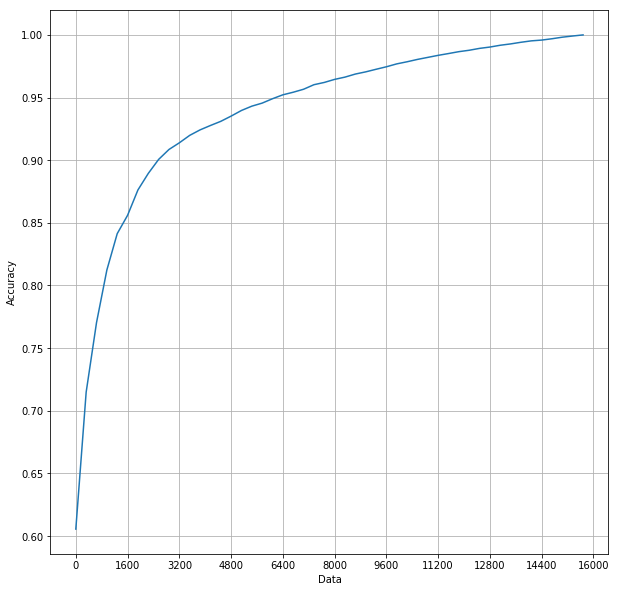

```python
#Plot for KNN Train set
fig, ax = plt.subplots()
ax.plot(train_accuracy_lst)
def format_fn(tick_val, tick_pos):
    return int(tick_val*320)
ax.xaxis.set_major_formatter(FuncFormatter(format_fn))
ax.xaxis.set_major_locator(MaxNLocator(integer=True))
plt.xticks(np.arange(0, 55, step=5))
plt.grid()
plt.xlabel('Data')
plt.ylabel('Accuracy')
plt.show()
```

If we use the plot from the previous analysis again, we can see that the model is learning and improving its accuracy through out the whole training data set till the last number of data. So we can say that we don't have too much training data.

```python
#Dividing into groups of data for analyzing
anl_data_lst = divDataInLst(sc_X_train, 40)
anl_target_lst = divDataInLst(y_train, 40)
#Using MLP to analyze overfitting
mlp_anl = MLPClassifier(random_state=0)
#Making lists of accuracy scores so it can be used to make plot
train_accuracy_lst = listOfAccuracy(mlp_anl, anl_data_lst, anl_target_lst, sc_X_train, y_train)
test_accuracy_lst = listOfAccuracy(mlp_anl, anl_data_lst, anl_target_lst, sc_X_test, y_test)
```

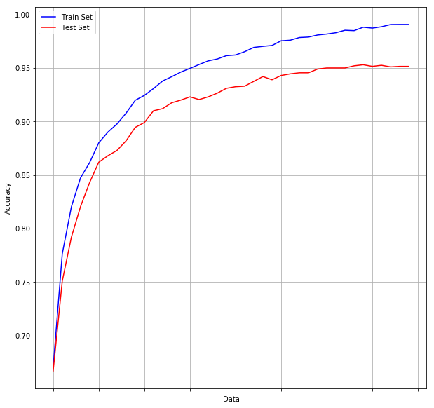

```python
#Plot for MLP Train and Test Set
from matplotlib.ticker import FuncFormatter, MaxNLocator
fig, ax = plt.subplots()
ax.plot(train_accuracy_lst, 'b', label='Train Set')
ax.plot(test_accuracy_lst, 'r', label='Test Set')
ax.xaxis.set_major_formatter(plt.NullFormatter())

plt.legend()
plt.grid()
plt.xlabel('Data')
plt.ylabel('Accuracy')
plt.rcParams["figure.figsize"] = (10,10)
plt.show()
```

As we can see from the above plot that training set scored 99% and test set scored 95% accuracy score with MLP classifier, which is reasonably a good score and the accuracy difference between the training set and testing set is not too much. So we can say that we don't have too little training data.